# Praktikum 4-ARMA

#### Korelasi antara $Y_t$ dengan $Y_{t-3}$

```r
#Yt
yt_ar3 <- ar[-c(1,2,3)]
yt_ar3
```

```
##   [1]  1.36575428  1.39590922  1.13570952  0.28279132  1.50040925  1.82335656
##   [7]  2.26520791  2.37882469  1.92603386  0.90130163 -0.72771580 -2.42441791
##  [13] -2.03891642 -2.28349806 -2.76423401 -1.01483256  0.45915055 -0.13143878
##  [19]  0.64966794  2.10013506  1.34229585  2.00424641  2.69991443  1.69154243
##  [25]  1.41871080  1.51068196 -1.45105252  0.60400821 -0.58648358 -1.06789694
##  [31]  1.43732902  1.06829989 -1.68754178 -0.41485893 -0.63005856 -0.28521680
##  [37] -0.69433910  0.11460675 -0.95643789 -0.72668464 -0.84042117 -1.96768974
##  [43] -2.20888318 -1.94326846 -1.37453823  0.54195167 -0.56167091  1.82161754
##  [49]  0.35596238  0.78190423  0.73165278  1.25634130  1.65000908 -1.34869234
##  [55]  0.05281962 -0.49949114  0.03783169  1.11090049 -0.16643084  1.74418214
##  [61]  1.35011369  2.12070193  1.41018017  2.32548506  3.13887744  0.51464665
##  [67]  0.26367212  1.14993103  0.60154084  2.10316064 -0.10711197  0.18079166
##  [73]  1.95401784  0.43015785 -0.52656290 -0.29162610 -0.44875789 -1.98836830
##  [79] -2.37755641 -0.69542107 -0.76181699 -1.12549995 -1.08838605 -0.28863280
##  [85]  0.26352053 -0.60751761  1.28780430  0.90909945  0.12273935  2.21878238
```

[output cut: 35 more lines]

```r
#Yt-2
yt_3_ar <- ar[-c(298,299,300)]
yt_3_ar
```

```
##   [1]  2.00000000  3.00000000  0.59629607  1.36575428  1.39590922  1.13570952
##   [7]  0.28279132  1.50040925  1.82335656  2.26520791  2.37882469  1.92603386
##  [13]  0.90130163 -0.72771580 -2.42441791 -2.03891642 -2.28349806 -2.76423401
##  [19] -1.01483256  0.45915055 -0.13143878  0.64966794  2.10013506  1.34229585
##  [25]  2.00424641  2.69991443  1.69154243  1.41871080  1.51068196 -1.45105252
##  [31]  0.60400821 -0.58648358 -1.06789694  1.43732902  1.06829989 -1.68754178
##  [37] -0.41485893 -0.63005856 -0.28521680 -0.69433910  0.11460675 -0.95643789
##  [43] -0.72668464 -0.84042117 -1.96768974 -2.20888318 -1.94326846 -1.37453823
##  [49]  0.54195167 -0.56167091  1.82161754  0.35596238  0.78190423  0.73165278
##  [55]  1.25634130  1.65000908 -1.34869234  0.05281962 -0.49949114  0.03783169
##  [61]  1.11090049 -0.16643084  1.74418214  1.35011369  2.12070193  1.41018017
##  [67]  2.32548506  3.13887744  0.51464665  0.26367212  1.14993103  0.60154084
##  [73]  2.10316064 -0.10711197  0.18079166  1.95401784  0.43015785 -0.52656290
##  [79] -0.29162610 -0.44875789 -1.98836830 -2.37755641 -0.69542107 -0.76181699
##  [85] -1.12549995 -1.08838605 -0.28863280  0.26352053 -0.60751761  1.28780430
```

[output cut: 35 more lines]

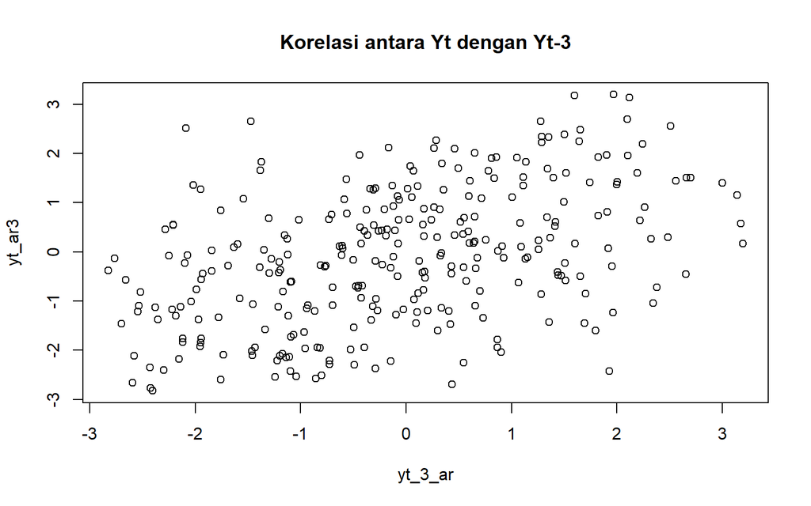

```r
plot(y=yt_ar3,x=yt_3_ar, main="Korelasi antara Yt dengan Yt-3")
```

```r
cor(yt_ar3,yt_3_ar)
```

```
## [1] 0.4496025
```

### Kesimpulan

Berdasarkan scatterplot tersebut, terdapat hubungan linear positif antara $Y_t$ dengan $Y_{t-1}$, $Y_{t-2}$, $Y_{t-3}$. Penurunan tingkat korelasi antara $Y_t$ dengan $Y_{t-1}$, $Y_{t-2}$, $Y_{t-3}$ cukup jauh menurun sebesar 0.1.

## Fungsi pembangkitan ARMA

Setelah mengetahui cara membangkitkan data berpola AR, MA, dan ARMA sederhana, bagaimana cara melakukan pembangkitan data berpola tersebut yang lebih kompleks? Apakah dapat dibuat suatu fungsi yang fleksibel yang memungkinan pembangkitan dengan berapapun jumlah koefisien?

Pertama, lihat kembali bentuk umum data berpola ARMA.

$$y_{t} = c + \sum_{i=1}^p \phi_{i}y_{t-i} + \sum_{j=1}^q e_{t-j}+ e_{t}$$

Komponen $c$ dan $e_{t}$ cukup mudah untuk dibuat dan dicari. Bagaimana untuk komponen AR dan MA? Bayangkan ada koefisien dan data sebagai berikut:

$$\begin{aligned}
\begin{bmatrix}
\phi_1 \ \phi_2 \ \phi_3
\end{bmatrix}&=
\begin{bmatrix}
0.4 \ 0.6 \ 0.5
\end{bmatrix}
\\
\begin{bmatrix}
y_{t-1} \ y_{t-2} \ y_{t-3}
\end{bmatrix}&=
\begin{bmatrix}
1 \ 2 \ 3
\end{bmatrix}
\end{aligned}$$

Maka dari itu,

$$\begin{aligned}
\begin{bmatrix}
\phi_1 \ \phi_2 \ \phi_3
\end{bmatrix}
\begin{bmatrix}
y_{t-1} \\ y_{t-2} \\ y_{t-3}
\end{bmatrix} &= \phi_1 \ y_{t-1}+\phi_2 \ y_{t-2}+\phi_3 \ y_{t-3}
\\
\begin{bmatrix}
0.4 \ 0.6 \ 0.5
\end{bmatrix}
\begin{bmatrix}
1 \\ 2 \\ 3
\end{bmatrix} & = 0.4 \cdot1+0.6 \cdot 2+0.5 \cdot 3\\
&=0.4+1.2+1.5 = 3.1
\end{aligned}$$

Jika koefisien dan *white noise*/nilai deret waktu sebelumnya dapat diekstrak dalam bentuk vektor, dapat dilakukan perkalian matriks untuk mencari nilai bagian AR dan MA:

```r
#membuat fungsi dari model ARMA(2,2)
set.seed(1105)

arma_sim <- function(ar_params, ma_params, n) {
  wn <- rnorm(n)
  arma <- rep(0, n)
  for(t in (max(length(ar_params), length(ma_params)) + 1):n) {
    ar_part = sum(ar_params * arma[(t - length(ar_params)):(t - 1)])
    ma_part = sum(ma_params * wn[(t - length(ma_params)):(t - 1)])
    arma[t] = ar_part + ma_part + wn[t]
  }

  return(arma)
}

ar_params <- c(0.5, 0.2)
ma_params <- c(0.4, 0.6)
n <- 300

arma <- arma_sim(ar_params, ma_params, n)
arma
```

```
##   [1]  0.000000000  0.000000000 -0.399369880 -0.315559382  0.090058226
##   [6]  0.568142226 -0.069316145  1.129374021  1.661235301  3.013086731
##  [11]  3.353490560  3.411130173  2.344258800  0.401787291 -2.141469601
##  [16] -2.878486130 -3.730615015 -4.140027250 -2.909812430 -1.124052725
##  [21] -0.596522503  0.455163283  1.905275563  2.101307683  3.103983170
##  [26]  3.713543313  3.458263999  3.117555540  2.811729576 -0.078018445
##  [31]  1.108785014 -0.795144818 -0.448100329  0.824796784  1.399085770
##  [36] -0.643583441 -0.494130435 -1.380250368 -0.375302679 -1.157282439
##  [41] -0.110605853 -1.334631636 -0.911012508 -1.648091195 -2.467296296
##  [46] -3.330060772 -3.539978565 -3.024108447 -0.911728479 -1.265865275
##  [51]  1.597531692  0.217403450  1.613963811  0.667757518  1.932212197
##  [56]  2.144112783 -0.211078134  0.322228802 -1.028943464  0.237507139
##  [61]  0.788655582  0.372972324  2.113224416  1.791791339  3.460651385
##  [66]  2.530441122  3.919275849  4.492849944  2.833279988  1.957360379
##  [71]  1.742466066  1.601543016  3.114316444  1.077613106  1.447957695
```

[output cut: 45 more lines]

```r
#---ARIMA.SIM---#
set.seed(1105)
arma_sim <- arima.sim(list(order = c(2,0,2), ar=c(0.5,0.2) , ma=c(0.4,0.6)), n = 300)
arma_sim
```

```
## Time Series:
## Start = 1
## End = 300
## Frequency = 1
##   [1]  3.7106801594  3.0895877798  0.0017755170  0.9279599759 -1.2170642545
##   [6] -0.9412689517  0.6573778548  1.0018055143 -0.3983487716 -0.4492954543
##  [11] -1.8088319443 -0.7863879083 -1.1866380610 -0.3343939894 -1.3273015812
##  [16] -1.0405742212 -1.7050175822 -2.7399145949 -3.5002465377 -4.0074620798
##  [21] -3.4771957247 -1.1738400993 -1.1696249187  1.9221112238  0.7476000263
##  [26]  2.0172545049  1.2579879402  2.0181419277  2.5915349625  0.0651143150
##  [31]  0.5033467896 -1.2875797206 -0.1302737806  0.8263378882  0.3006279165
##  [36]  2.3441497565  1.9479277781  3.7072564848  3.0685290001  4.1619781656
##  [41]  4.9151794721  3.1654885873  2.3528571891  1.5641878293  1.2197164989
##  [46]  3.0337355716  1.0950767738  1.3998432456  1.9620673138  1.3202399816
##  [51]  0.8179109445 -0.2441565547 -0.8813460703 -2.3428471166 -3.4421584582
```

[output cut: 49 more lines]

## Karakteristik ARMA(2,2)

### TS, ACF, PACF

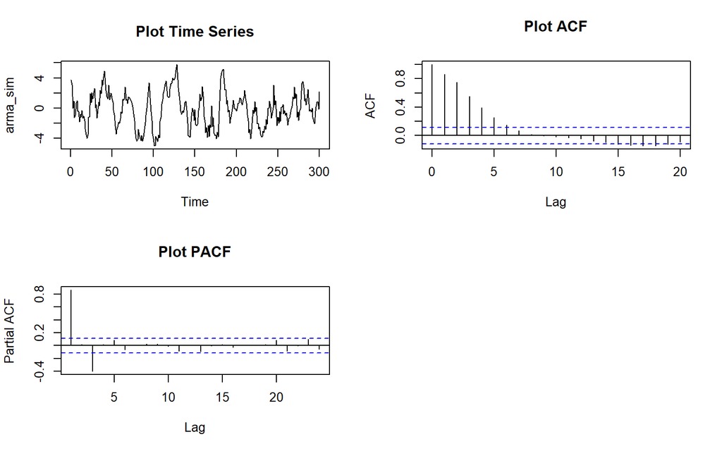

```r
par(mfrow=c(2,2))

# Plot Time Series
ts.plot(arma_sim, main="Plot Time Series")

# Plot ACF
acf(arma_sim, lag.max = 20, main="Plot ACF")

# Plot PACF
pacf(arma_sim, main="Plot PACF")

# Reset the plot layout
par(mfrow=c(1,1))
```

### Plot EACF

```r
TSA::eacf(arma_sim)
```

```
## AR/MA
##   0 1 2 3 4 5 6 7 8 9 10 11 12 13
## 0 x x x x x x o o o o o  o  o  o
## 1 o x o x o o o o o o o  o  o  o
## 2 o x o x o o o o o o o  o  o  o
## 3 x x x x o o o o o o o  o  o  o
## 4 x x o o o o o o o o o  o  o  o
## 5 x x o x x o o o o o o  o  o  o
## 6 x x o x o o o o o o o  x  o  o
## 7 x x x x o o x o o o o  x  o  o
```

Berdasarkan pola segitiga nol pada plot EACF, terlihat bahwa segitiga nol berada pada ordo AR(1) dan ordo MA(4)

## Scatterplot dan Korelasi

```
##        Yt_1      Yt_2      Yt_3
## 1 0.9110933 0.8220504 0.6734342
```

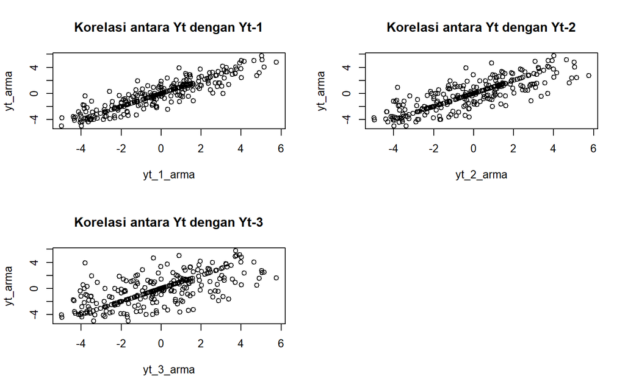

```r
par(mfrow=c(2,2))

# Korelasi antara Yt dengan Yt-1
# Yt
yt_arma <- arma_sim[-1]
# Yt-1
yt_1_arma <- arma_sim[-200]
plot(y=yt_arma,x=yt_1_arma, main="Korelasi antara Yt dengan Yt-1")
cor_1 <- cor(yt_arma,yt_1_arma)

# Korelasi antara Yt dengan Yt-2
# Yt
yt_arma <- arma_sim[-c(1,2)]
# Yt-2
yt_2_arma <- arma_sim[-c(199,200)]
plot(y=yt_arma,x=yt_2_arma, main="Korelasi antara Yt dengan Yt-2")
cor_2 <- cor(yt_arma,yt_2_arma)

# Korelasi antara Yt dengan Yt-3
# Yt
yt_arma <- arma_sim[-c(1,2,3)]
# Yt-3
yt_3_arma <- arma_sim[-c(198,199,200)]
plot(y=yt_arma,x=yt_3_arma, main="Korelasi antara Yt dengan Yt-3")
cor_3 <- cor(yt_arma,yt_3_arma)


# Tabel Korelasi
cor_table <- data.frame(Yt_1 = cor_1, Yt_2 = cor_2, Yt_3 = cor_3)
print(cor_table)
```